# Immigration Plots

Plots are based on Department of Homeland Security, Yearbook of Immigration Statistics, 1998 - 2019

Kasey Zapatka

2021-03-29

# Description

This file explores some of the interesting patters in the United States immigration data associated with the Superdiversity project. Using data from the Yearbook of Immigration Statistics between 1998 and 2019, we explore immigration over time by region and for the top 25 sending countries, for both temporary and permanent immigration categories.

### Immigration by region

The following line graphs report the number of visas receive by region (Africa, Americas, Asia, Europe, Oceania, and an unknown category) for family, diversity, and refugee/asylee-based immigration.

**Family-based immigration by region**

Salient here is that immigration from sending countries by region is relatively unchanged over the study period. American and Asian sending countries dominate the number of family-based immigrants and remain unchanged, whereas immigration for European countries dips below that of African countries after around 2010.

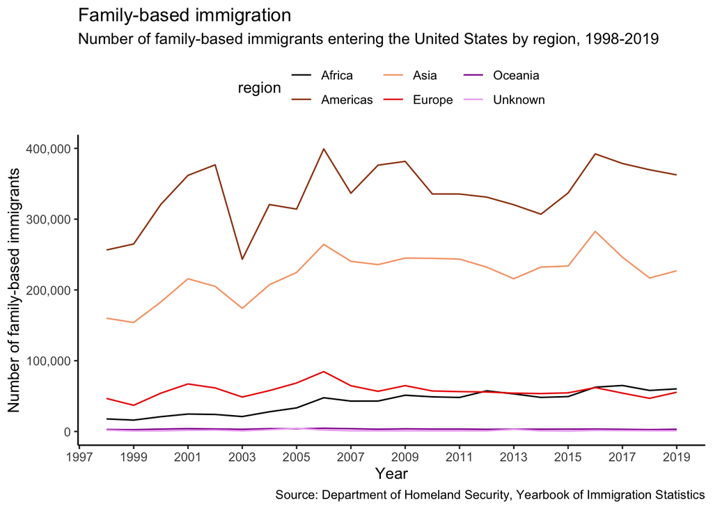

**Diversity-based immigration by region**

Before about 2004, most diversity-based visa were issued to immigrants from European sending countries. That changed abound 2006, where immigrants from African sending countries began to receive more diversity-based visas. In 2018, European immigration via diversity-based immigration peak and then precipitously decline while African diversity-based visas increased once again Immigration from Asian sending countries remained consistent over the study period.

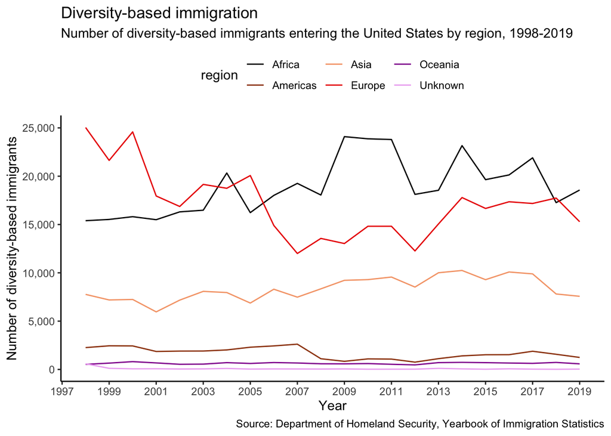

**Refugee/Asylee-based immigration by region**

[figure not shown]

**Temporary workers by region**

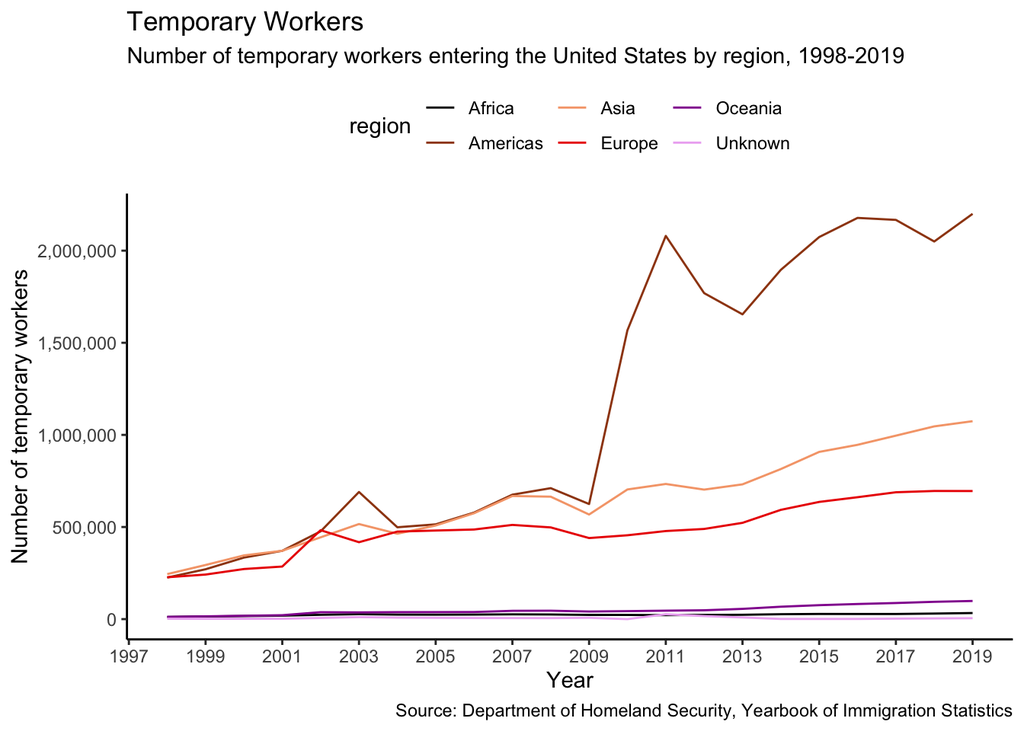

**Student visas by region**

Around 2009, there was a dramatic rise in student visas being issued to students from American countries; however, the most telling story is the steady increase of visas issued to students from Asian sending countries.

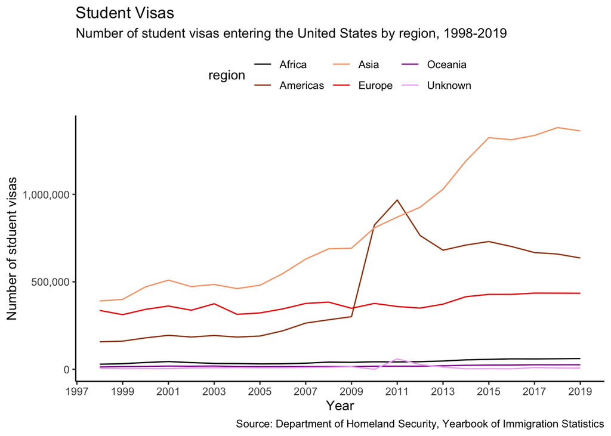

### Top 25

The following bar charts report the top 25 sending countries by year that received the most number of student, temporary worker, and diplomat visas. Note that the bar charts are animated, meaning they will reveal the top 25 for every year over the study period. You will notice there are more than 25 countries listed on the y-axis. This is because the 25 countries in a given year were not always the same.

**Top 25 Student Sending Countries by Year**

Asian countries like China, Korea, or Japan were receiving the majority of student visas until about 2009 or 2010 when Canada and Mexico received a larger share of students visa. After about 2012, China dominated the student visa reception.

[video not shown]

**Top 25 Temporary Worker Sending Countries by Year**

After about 2000, four countries were receiving the lion’s share of temporary workers: Canada, Mexico, India, and Japan. The explosion of Canada and Mexico in 2009 is likely the result of administrative changes in how temporary worker visas were classified.

[video not shown]

**Top 25 Diplomat Sending Countries by Year**

The United Kingdom consistently receives the highest number of diplomat visas across the entire study period. Other well-known allies of the United States like Korea (which later were reclassified to South Korea), Mexico, and several western European countries receive the majority of diplomat visas.

[video not shown]